# 04.05.01.00.RelatividadEspecial.CinematicaRelativista.Definiciones

Indice | Previo: RelatividadEspecial.OpticaRelativista | Siguiente: RelatividadEspecial.CinematicaRelativista.AceleracionPropiaConstante

## 4.11. Cinemática relativistica

Usando lo que vimos en la sección anterior, podemos reconstruir una cinemática en el espacio-tiempo.

### 4.11.1. Cuadrivelocidad

Definimos la cuadrivelocidad media de una partícula que se mueve entre dos eventos separados por un intervalo temporaloide como:

$$ \bar{U_L}^\mu=\frac{\Delta x_L^\mu}{\Delta \tau} $$

donde $\Delta\tau$ es el tiempo propio entre los eventos.

Usando el mismo método de la mecánica convencional podemos extender este concepto al de cuadrivelocidad instantánea:

$$ U^\mu=\lim_{\Delta \tau\rightarrow 0}\frac{\Delta x_L^\mu}{\Delta \tau}=\frac{\mathrm{d}x_L^\mu}{\mathrm{d}\tau} $$

En términos de componentes explícitas:

$$ U_L^\mu:\left(\frac{\mathrm{d}t}{\mathrm{d}\tau},\frac{\mathrm{d}\vec{r}_L}{\mathrm{d}\tau}\right) $$

$$ \vec{v}_L=\frac{\mathrm{d}x_L^\mu}{\mathrm{d}t} $$

la cuadrivelocidad queda:

$$ U_L^\mu:\gamma\left(1,\vec{v}_L\right) $$

**Proposición: Cuadrirapidez.** Todas las partículas del universo ($v_L<1$) tienen siempre cuadrirapidez unitaria:

> $$ |U_L^\mu|=1 $$

Naturalmente esto es en unidades luz. En unidades convencionales la cuadrirapidez sería igual a $c$.

Un gráfico de todas las cuadrivelocidades de todas las partículas en el universo son:

```python
%matplotlib inline
```

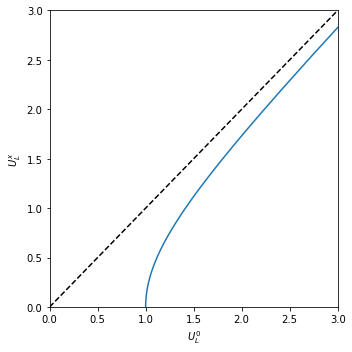

```python
from numpy import linspace
vl=linspace(0,0.95)
gamma=1/(1-vl**2)**0.5
U0=gamma
Ux=gamma*vl

import matplotlib.pyplot as plt
fig=plt.figure(figsize=(5,5))
ax=fig.gca()

ax.plot(U0,Ux)
ax.set_xlim((0,3))
ax.set_ylim((0,3))
ax.plot([0,3],[0,3],'k--')
ax.set_xlabel("$U_L^0$")
ax.set_ylabel("$U_{L}^{x}$")
fig.tight_layout()
```

**Figura 4.15.**

Nótese que en realidad si incluímos las 3 dimensiones espaciales todas las cuadrivelocidades del universo estarían en un hiper-hiperboloide de revolución:

$$ 1 = (U_L^0)^2 - (U_L^1)^2-(U_L^2)^2-(U_L^3)^2 $$

Si fijas el valor de $U_L^0=\gamma$, los puntos satisfacen:

$$ v_{Lx}^2+v_{Ly}^2+v_{Lz}^2=\mathrm{cte} $$

que son puntos sobre una esfera.

### 4.11.2. Cuadriaceleración

De la misma manera que definimos la cuadrivelocidad promedio, podemos definir la cuadriaceleración promedio:

$$ \bar{A_L}^\mu=\frac{\Delta U_L^\mu}{\Delta \tau} $$

La aceleración instantánea sería:

$$ A_L^\mu=\lim_{\Delta \tau\rightarrow 0}\frac{\Delta U_L^\mu}{\Delta \tau}=\frac{\mathrm{d}U_L^\mu}{\mathrm{d}\tau} $$

$$ A^\mu_L : \gamma^4 (\vec{a}_L\cdot \vec{v}_L,\vec{a}_L) $$

naturalmente aquí $\vec{a}_L\cdot \vec{v}_L$ es el producto punto euclidiano convencional y $\vec a_L=\mathrm{d}\vec{v}_L/\mathrm{d}t$ es la aceleración espacial clásica.

**Nota: De unidades luz a unidades convencionales.** Si en un problema dado obtenemos el desplazamiento, la velocidad (cuadrivelocidad) o la acelaración (cuadriaceleración) en unidades luz, podemos volver a obtener las unidades originales como:

> $$ \begin{array}{rcl} \Delta \vec{r} & = & c \Delta \vec{r}_L\\ \vec{v} & = & c \vec{v}_L\\ \vec{a} & = & c \vec{a}_L\\ \end{array} $$

> Con estas transformaciones, la cuadriaceleración se puede escribir como:

> $$A^\mu : c\gamma^4\left(\frac{\vec{a}\cdot\vec{v}}{c^2},\frac{\vec{a}}{c}\right)$$

Nótese que si $\vec{v}_L=\vec{o}$ entonces:

$$ A_L^\mu:(0,\vec \alpha_L) $$

de donde vemos que el módulo cuadrado de la cuadriaceleración es espacialoide:

$$ |A_L^\mu|^2 = -\alpha_L^2 $$

Dado que esta cantidad es invariante (la misma para el Observador y el viajero) llamamos a $\alpha_L$ la aceleración propia de la partícula.

**Proposición: La relación entre la cuadriaceleración y la cuadrivelocidad.** La cuadrivelocidad y la cuadriaceleración son perpendiculares:

> $$A^\mu\cdot U^\nu = 0$$

Indice | Previo: RelatividadEspecial.OpticaRelativista | Siguiente: RelatividadEspecial.CinematicaRelativista.AceleracionPropiaConstante